# STAT-627 Celestial Classification

Max Calzada, Josiah Gottfried, Sanghyeob Ko, Domingo Salerno

2022-12-09

# Introduction

For our project, our central question was “Which statistical model would most optimally classify whether a celestial body is a star, quasar, or galaxy.”

To answer this question we built the following models:

- KNN
  - KNN with PCA
- LDA/QDA
  - LDA/QDA with PCA
- Logistic Regression
  - Logistic Regression with PCA
- Trees/Random Forests
  - Trees/Random Forests with PCA

## Data source

The data consists of 100,000 observations of celestial objects by the SDSS (Sloan Digital Sky Survey). Every observation is described by 17 feature columns and 1 class column which identifies it to be either a star, galaxy or quasar. We dropped the columns irrelevant to the classification question, leaving us with six predictor variables. The variables “u”, “r”, “g”, “i”, and “z” measure the light reaching the telescope at different wavelengths. The “redshift” variable is the increase in wavelength due to the distance that the light travels.

https://www.kaggle.com/datasets/fedesoriano/stellar-classification-dataset-sdss17

# Load data

```r
Space_DF <- read.csv("star_classification.csv") # Upload data
Space_DF <- Space_DF[, c("class", "u", "r", "g", "i", "z", "redshift")]

# Cleaning
Space_DF <- subset(Space_DF, u != -9999) # Remove point with NAs
Space_DF$class <- as.factor(Space_DF$class) # Convert class to a factor

# Display
head(Space_DF)
```

```
##    class        u        r        g        i        z  redshift
## 1 GALAXY 23.87882 20.39501 22.27530 19.16573 18.79371 0.6347936
## 2 GALAXY 24.77759 22.58444 22.83188 21.16812 21.61427 0.7791360
## 3 GALAXY 25.26307 20.60976 22.66389 19.34857 18.94827 0.6441945
## 4 GALAXY 22.13682 21.61162 23.77656 20.50454 19.25010 0.9323456
## 5 GALAXY 19.43718 16.49747 17.58028 15.97711 15.54461 0.1161227
## 6    QSO 23.48827 21.32195 23.33776 20.25615 19.54544 1.4246590
```

```r
# Create indicator variables for logistic regression
Space_DF$galaxy <- ifelse(Space_DF$class == "GALAXY", 1, 0)
Space_DF$star <- ifelse(Space_DF$class == "STAR", 1, 0)
Space_DF$quasar <- ifelse(Space_DF$class == "QSO", 1, 0)
```

# Data exploration

Here we visually explore the relationships between some of the predictors and the class variable.

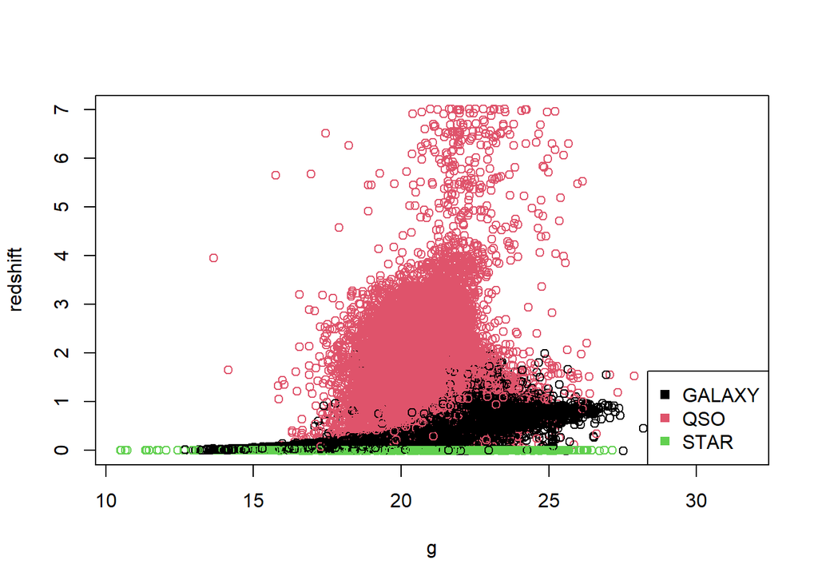

```r
plot(redshift ~ g, data = Space_DF, col = class)
legend("bottomright", legend = levels(Space_DF$class), col = 1:3, pch = 15)
```

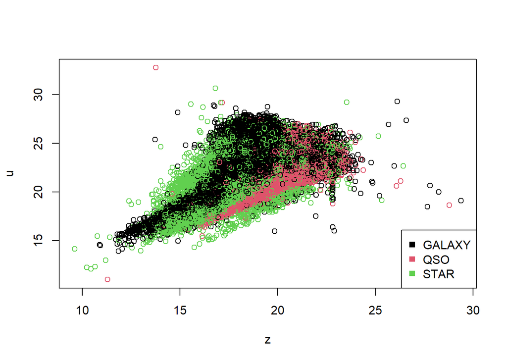

```r
plot(u ~ z, data = Space_DF, col = class)
legend("bottomright", legend = levels(Space_DF$class), col = 1:3, pch = 15)
```

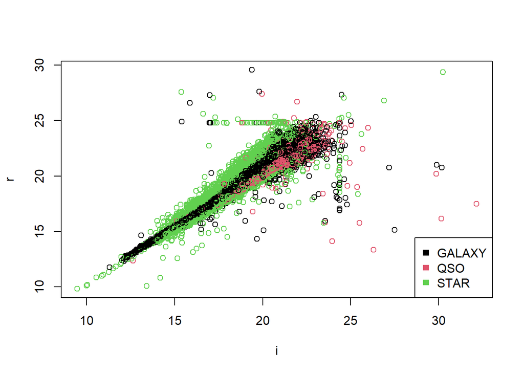

```r
plot(r ~ i, data = Space_DF, col = class)
legend("bottomright", legend = levels(Space_DF$class), col = 1:3, pch = 15)
```

The plots suggest that redshift is an important predictor of class. They show some potential multicollinearity, so we will also run a principle components analysis.  
We also need to test normality assumptions for discriminant analysis.

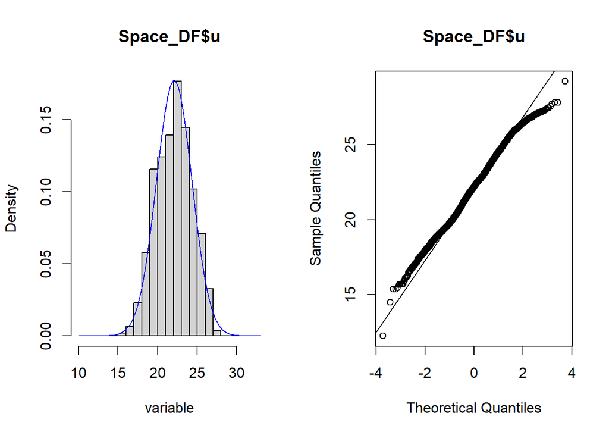

```r
norm_plots <- function(variable){

  # Histogram with normal curve
  hist(variable, freq = F, main = paste(deparse(substitute(variable))))
  curve(dnorm(x, mean = mean(variable), sd = sd(variable)), add = TRUE, col = "blue")

  # Theoretical quantiles plot (with the first 5000 points to save computing power)
  qqnorm(variable[1:5000], main = paste(deparse(substitute(variable))))
  qqline(variable[1:5000])

}

par(mfrow = c(1,2))
norm_plots(Space_DF$u)
```

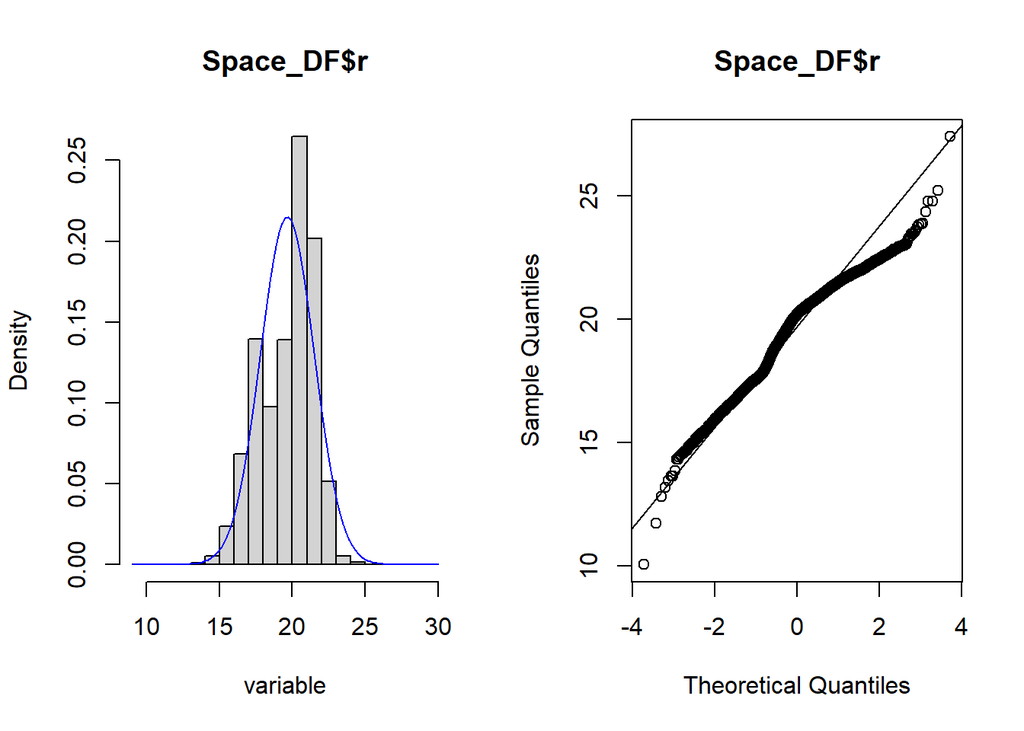

```r
norm_plots(Space_DF$r)
```

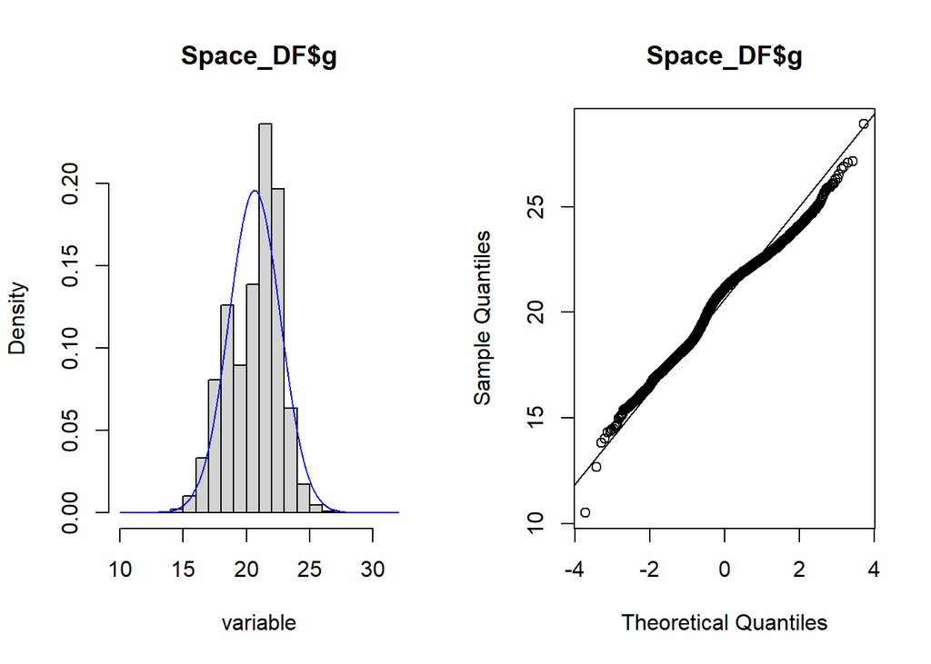

```r
norm_plots(Space_DF$g)
```

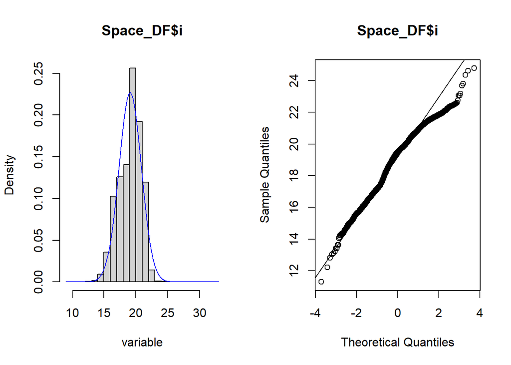

```r
norm_plots(Space_DF$i)
```

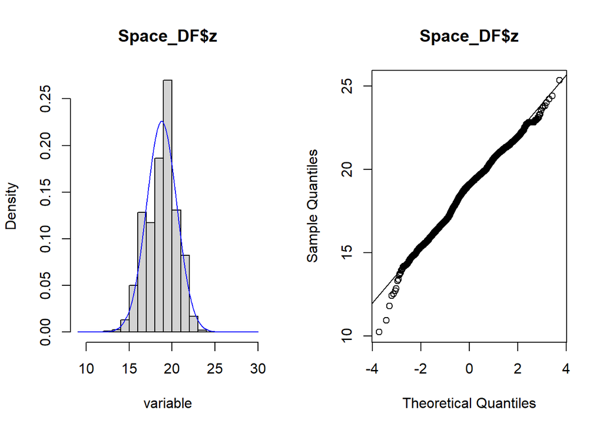

```r
norm_plots(Space_DF$z)
```

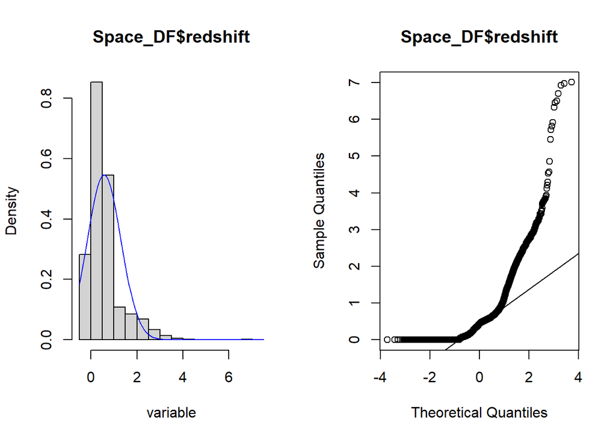

```r
norm_plots(Space_DF$redshift)
```

All variables look reasonably normal except redshift.

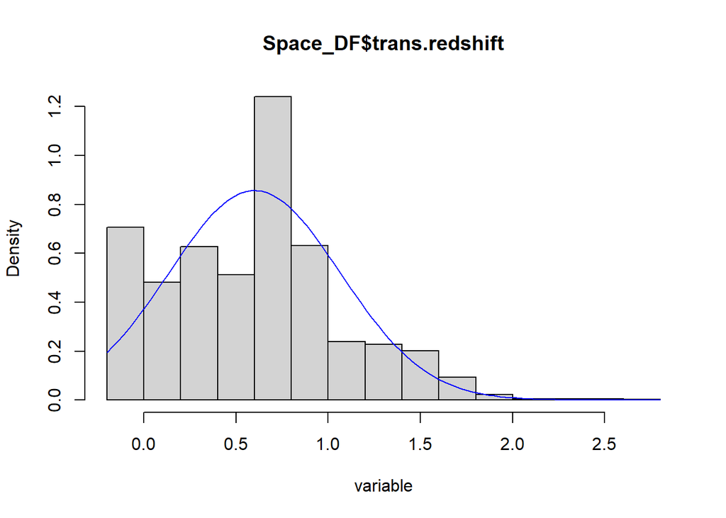

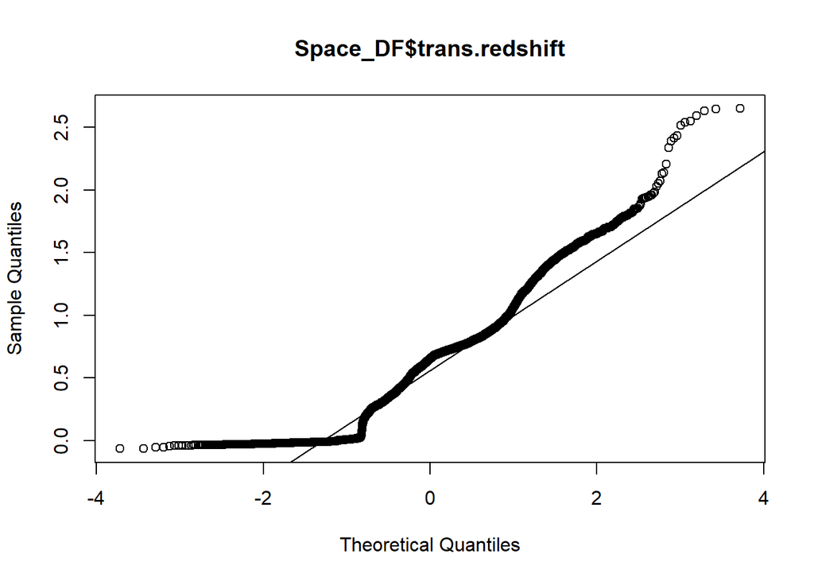

```r
# Since the data contain negative values, let's try signed square root
signsqrt <- function(x){
  sign(x) * abs(x)^(1/2)
}

# Transform redshift
Space_DF$trans.redshift <- signsqrt(Space_DF$redshift)
norm_plots(Space_DF$trans.redshift)
```

With the signed square root transformation, the data look closer to normal.

# Split data into training and testing sets

To test our results, we will use both validation set and 10-fold cross-validation.

```r
set.seed(1)
n.S <- nrow(Space_DF)
Z.S <- sample(n.S, n.S*0.9) # We’ll split data at random

S.Train <- Space_DF[Z.S,] # training data
S.Test <- Space_DF[-Z.S,] # testing data
X.S.Train <- S.Train[, c("u", "r", "g", "i", "z", "trans.redshift")]
X.S.Test <- S.Test[, c("u", "r", "g", "i", "z", "trans.redshift")]
Y.S.Train <- Space_DF$class[Z.S]
Y.S.Test <- Space_DF$class[-Z.S]
```

```r
# Set up folds for 10-fold validation
set.seed(1)
fold <- sample(rep(1:10, 10000), n.S)
```

```r
# Initialize matrix for cross validation results
CV.results <- as.data.frame(matrix(nrow = 12, ncol = 2))
rownames(CV.results) <- c("KNN", "LDA", "QDA", "Logistic", "Tree", "RF",
                          "KNN.PC", "LDA.PC", "QDA.PC", "Logistic.PC", "Tree.PC", "RF.PC")
colnames(CV.results) <- c("ValSet", "KFold")
```

# Calculate principal components

We will try each of our models using the original data against models using the first three principal components. In addition to addressing multicollinearity issues, we hope that the principal components will allow us to cut the size of the data in half.

```r
X.pca <-  model.matrix(class ~ u + r + g + i + z + trans.redshift, data = Space_DF)[,-1]
pc <-  prcomp(X.pca, scale = TRUE)
summary(pc)
```

```
## Importance of components:
##                           PC1    PC2     PC3     PC4     PC5     PC6
## Standard deviation     2.1425 0.8855 0.70420 0.30458 0.15058 0.11884
## Proportion of Variance 0.7651 0.1307 0.08265 0.01546 0.00378 0.00235
## Cumulative Proportion  0.7651 0.8958 0.97841 0.99387 0.99765 1.00000
```

```r
pc_df <- cbind(pc$x, Space_DF[c("class", "galaxy", "star", "quasar")])
head(pc_df)
```

```
##          PC1        PC2        PC3          PC4          PC5          PC6
## 1 -0.9754941 -0.3092518 -0.7252606  0.213995819 -0.098556788  0.064624597
## 2 -3.0306230 -0.1585065  0.2371722 -0.273078122 -0.028418457  0.373316990
## 3 -1.4235023 -0.6545906 -1.0106029  0.002352025 -0.082477059  0.053752834
## 4 -1.8733837  0.2653299 -0.1266251  1.110577519 -0.004385908 -0.142861629
## 5  3.5966664  0.2142791 -0.5284558  0.099998231  0.040808228 -0.002433913
## 6 -2.0717346  0.4145124 -0.6872419  0.538093220 -0.084881086 -0.047709375
##    class galaxy star quasar
## 1 GALAXY      1    0      0
## 2 GALAXY      1    0      0
## 3 GALAXY      1    0      0
## 4 GALAXY      1    0      0
## 5 GALAXY      1    0      0
## 6    QSO      0    0      1
```

```r
# Training set / Testing set of PC data
n.PC <- length(pc_df$class)
S.Train.PC <- pc_df[Z.S,]
S.Test.PC <- pc_df[-Z.S,]
X.S.Train.PC <- S.Train.PC[, c("PC1", "PC2", "PC3")]
X.S.Test.PC <- S.Test.PC[, c("PC1", "PC2", "PC3")]
```

The first three principal components explain 98% of the variance.

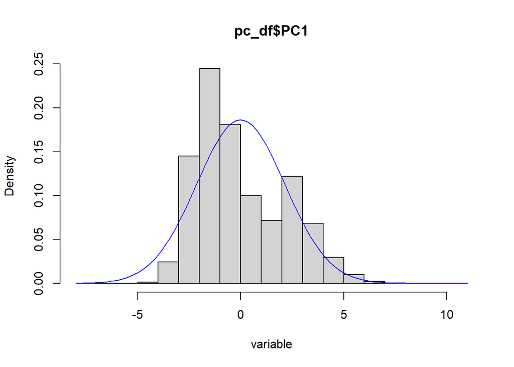

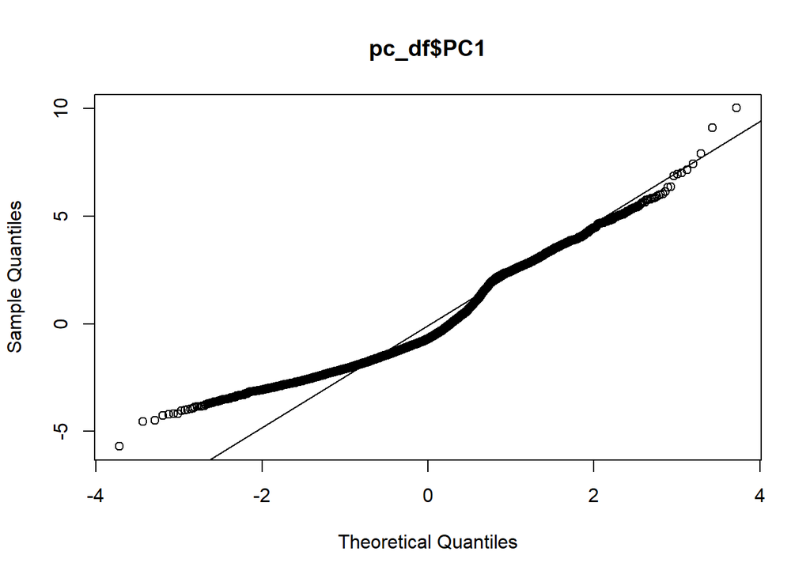

```r
norm_plots(pc_df$PC1)
```

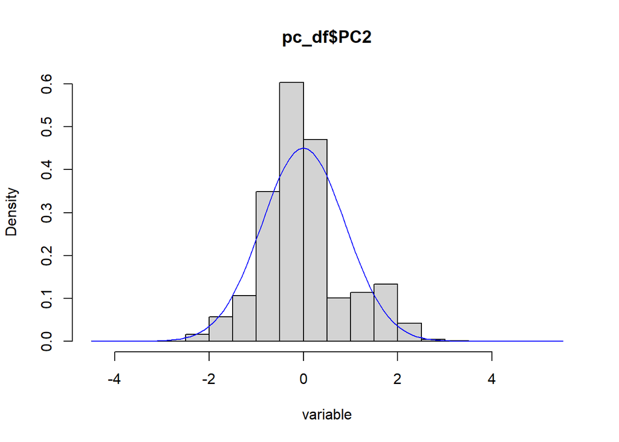

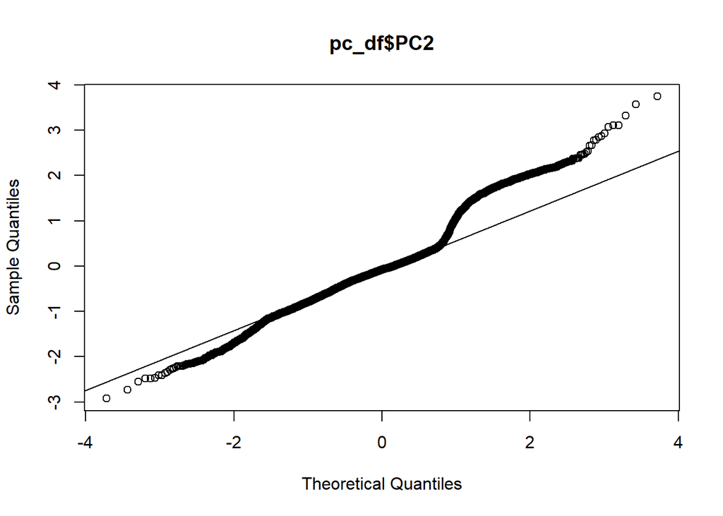

```r
norm_plots(pc_df$PC2)
```

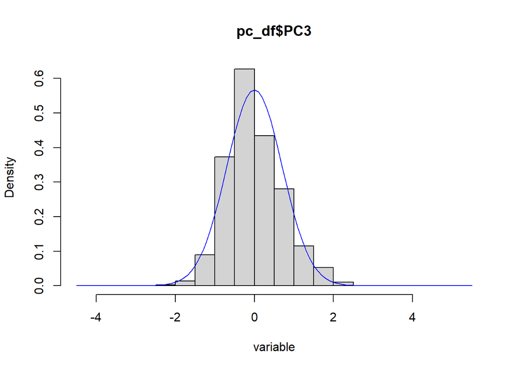

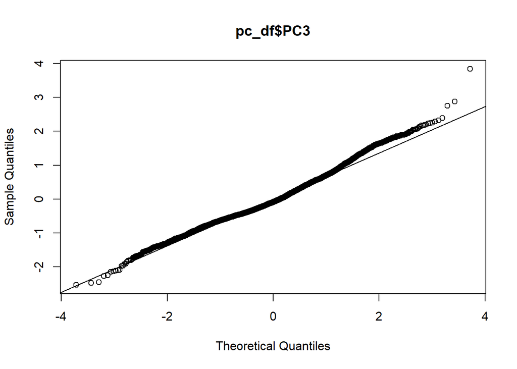

```r
norm_plots(pc_df$PC3)
```

# Models

## KNN

```r
set.seed(1)
knn.S = knn(X.S.Train, X.S.Test, Y.S.Train, 3) # K = 3?
table(Y.S.Test, knn.S)
```

```
##         knn.S
## Y.S.Test GALAXY  QSO STAR
##   GALAXY   5729   80   79
##   QSO       184 1685    4
##   STAR       28    3 2208
```

```r
mean(Y.S.Test == knn.S )
```

```
## [1] 0.9622
```

```r
# Tuning
class.rate = rep(0,10)

set.seed(1)
for (K in 1:10) {
  knn.S = knn(X.S.Train, X.S.Test, Y.S.Train, K)
  class.rate[K] = mean(Y.S.Test == knn.S)
}

class.rate
```

```
##  [1] 0.9527 0.9525 0.9622 0.9613 0.9630 0.9632 0.9614 0.9612 0.9608 0.9608
```

```r
which.max(class.rate)
```

```
## [1] 6
```

```r
CV.results["KNN", "ValSet"] <- max(class.rate)
```

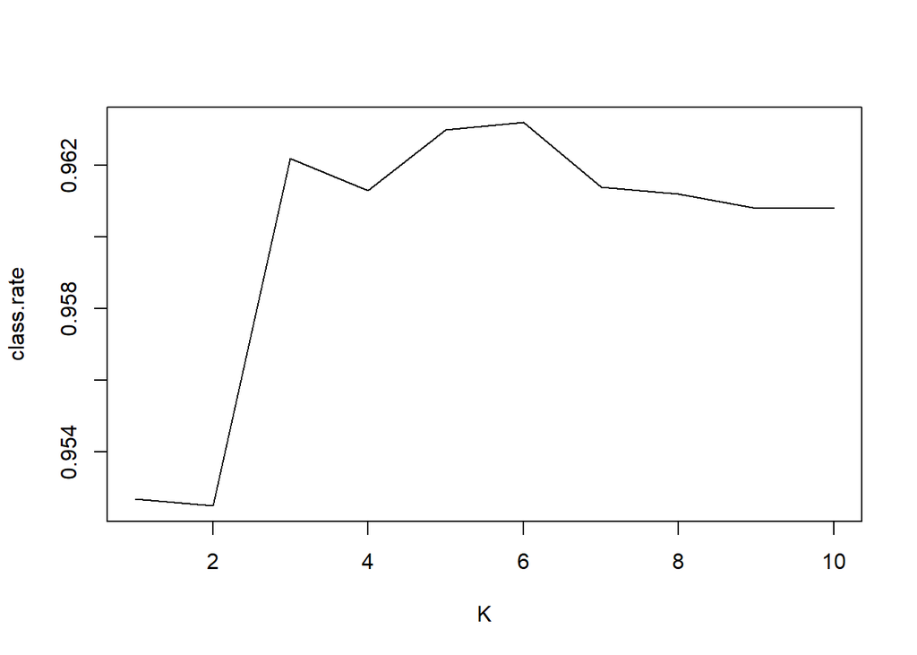

```r
plot(class.rate, type = "l", xlab = "K")
```

### KNN, with PCA

```r
class.rate <- NULL

set.seed(1)
for (K in 1:12) {
  knn.S.pca = knn(X.S.Train.PC, X.S.Test.PC, Y.S.Train, K)
  class.rate[K] = mean(Y.S.Test == knn.S.pca)
}

class.rate
```

```
##  [1] 0.9535 0.9516 0.9649 0.9643 0.9669 0.9675 0.9672 0.9671 0.9665 0.9669
## [11] 0.9668 0.9666
```

```r
which.max(class.rate)
```

```
## [1] 6
```

```r
CV.results["KNN.PC", "ValSet"] <- max(class.rate)
```

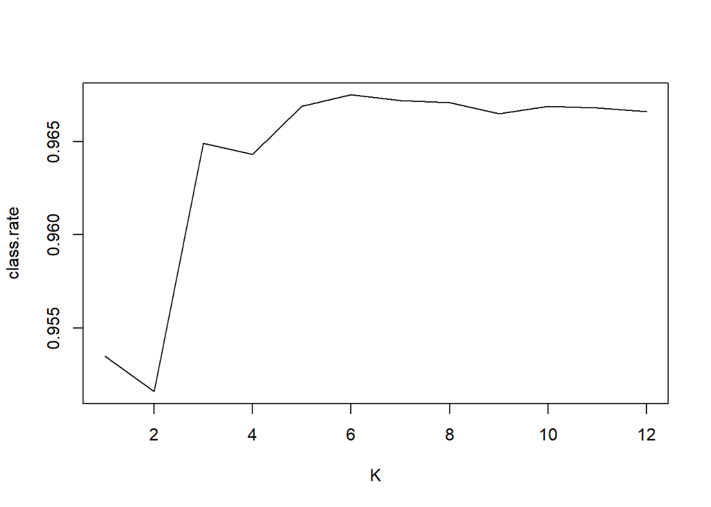

```r
plot(class.rate, type = "l", xlab = "K")
```

The benefit of KNN is that this is a parameter less classification method. It classifies data without assuming any distribution shapes about the data. Given the large n of 100,000 and the small p of 6, the KNN model will have the benefit of being able to closely follow a non-linear boundary and not follow noise too closely. Note however that as KNN reduces bias, it tends to incur variance.